# Recept

## Förvaring av körsbär

Hållbarhet och förvaring:

- 14 dagar vid 0°C.
- 2 dagar vid 20°C.
- Ideal förvaring vid 0°C och 95-100% relativ fuktighet.
- Kan frysas för senare matlagning.
- Surkörsbär och vissa sötkörsbär kan konserveras (som tex sylt).

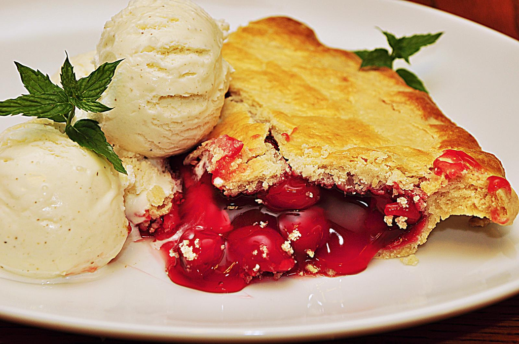

Körsbärspaj

## Körsbärspaj

Använd urkärnade sötkörsbär med rött fruktkött (färska eller frusna - då några minuters extra gräddning), eller surkörsbär (tag då något mer socker). Behöver stå en stund för att sätta sig. Kan göras i förväg (en dag i rumstemp, 5 dagar i kylen, tre månader i frysen).

### Pajskal (botten och lock)

**1. Blanda:**

- 6 dl (313g) vetemjöl
- 2 tsk socker
- 1 tsk salt

**2. Tillsätt:**

- 2.5 dl (226g) osaltat, kallt smör, skäres i kuber
- Knåda ihop (använd matberedare eller en gaffel) med mjölblandningen tills smörbitarna är ärtstora.

**3. Tillsätt gradvis:**

- 1.2 dl (120 ml) isvatten, mer om det behövs
- 3 msk (30 ml) åt gången, rör om efter varje, tills degen börjar klumpa ihop sig, blir litet fuktig och litt kladdig

**4. Bearbeta degen:**

- Vik/bearbeta på lätt mjölad yta tills allt mjöl gått in i degen
- Dela i hälften
- Slå in i plast och kyl minst 2 tim (håller upp till 5 dagar i kylen)

Man kan ersätta 1 msk av isvattnet med kall äppelcidervinäger för att få en frasigare deg.

### Fyllning

Skär ungefär hälften av bären i halvor och hälften i fjärdedelar. Sätt ugnen på 200 grader.

**1. Rör ihop ordentligt:**

- 10 dl delade körsbär
- 1.5 dl (135g) socker
- 0.6 dl (28g) majsstärkelse
- 1 tsk (15 ml) citronsaft
- 1 tsk vaniljextrakt
- 1/4 tsk mandelextrakt
- Täck över och förvara i kylen medans du kavlar ut pajdegen (eller upp till 24 tim)

**2. Kavla ut degen:**

- Två bitar kavlas till två rundlar, 30 cm diameter
- Lägg i en 23-cm pajform
- Använd en hålslev för att skopa upp körsbären i pajskalet. Spara saften
- Ställ i kylen

**3. Reducera saften:**

- Häll den saft som du sparat (några matskedar) i en liten stekpanna, låg värme
- Koka och rör 3-4 minuter tills saften har tjocknat något
- Kyl 5 minuter
- Häll över körsbären

**4. Sprid över fyllningen:**

- 1 msk (14g) kallt, osaltat smör, skär i små kuber

**5. Täcke:**

- Tag ut den andra hälften av degen ur kylen
- Kavla till en cirkel, 30 cm diameter
- Skär band av degen, tex 4 st med 5 cm bredd och 2 med 1.5 cm bredd
- Väv banden under- och över varandra
- Pressa ner kanterna av banden i botten
- Pressa en gaffel mot kanterna av pajskalet för att mönstra och försegla kanten
- Pensling: 1 stort ägg sammanslaget med 1 msk (15 ml) mjölk
- Valfritt: Grovkornigt socker som strös på locket

**6. Grädda**

- 20 minuter på 200 grader
- Lägg därefter över ett skydd av aluminiumfolie
- Sänk sedan till 190 grader och grädda ytterligare 30-40 minuter, eller tills locket är gyllenbrunt och fyllningen har bubblat upp i mellanrummen under minst 5 minuter

**7. Låt svalna**

- Minst 3-4 tim före den skärs upp, annars blir fyllningen för lös

Klart!

## Konservering

Sylt

Saft

Likör